# sentiment analysis

### Read the doctor review dataset

```python
import pandas as pd
import matplotlib.pyplot as plt
import numpy as np
import seaborn as sns
```

```python
path = "/Users/chongchen/Desktop/19Fall RA/raw data/"
doc_review = pd.read_csv(path + 'docs_before.csv', index_col = 0)
gender = pd.read_csv(path + 'genders.csv').drop_duplicates()
doc_review = pd.merge(doc_review,gender,on='hp_id',how='inner')
```

Number of records and number of columns

```python
doc_review.shape
```

```
(134973, 44)
```

Column Names

```python
doc_review.columns
```

```
Index(['hp_id', 'ratemds_id', 'order_id', 'hasorder', 'review_count',
       'avg_help', 'avg_know', 'avg_punct', 'avg_staff', 'var_help',
       'var_know', 'var_punct', 'var_staff', 'rem_neg_DONOTUSE',
       'rem_pos_DONOTUSE', 'ones', 'twos', 'threes', 'fours', 'fives',
       'prop_ones', 'prop_twos', 'prop_threes', 'prop_fours', 'prop_fives',
       'review_corpus', 'spec_comb', 'gy_comb', 'HP_ST', 'firstorderdate',
       'action_desc_concat', 'action_comment_concat', 'orderbasesconcat',
       'cat_nonprej', 'cat_otherprej', 'cat_restrictlicense',
       'cat_losslicense', 'cem_strata_alldocs', 'basecat_badmed',
       'basecat_impaired', 'basecat_finances', 'basecat_criminal',
       'basecat_patient', 'gender'],
      dtype='object')
```

```python
doc_review['hasorder'] = doc_review['hasorder'].map(lambda x: str(x))
```

```python
doc_review['hasorder'].value_counts()
```

```
0    133600
1      1373
Name: hasorder, dtype: int64
```

```python
def no_space(x):
    a = x.split(' ')
    b = ''
    for i in a:
        if i != '':
            b = b+i
    return b
doc_review['spec_comb'] = doc_review['spec_comb'].map(lambda x:no_space(x))
```

```python
doc_review['spec_comb'][2]
```

```
'InternalMedicine'
```

### Let's focus on the doctors who has speciality of 'Internal Medicine' first.

```python
review = doc_review[['hp_id','review_corpus']][doc_review['spec_comb']=='InternalMedicine']
```

```python
review.shape
```

```
(33549, 2)
```

```python
review.reset_index(inplace = True, drop = True)
```

```python
review
```

|  | hp_id | review_corpus |
| --- | --- | --- |
| 0 | 19713 | satisfactory but would not recommend coldness,... |
| 1 | 587845 | I have been going to Dr. Mittleman for the pas... |
| 2 | 1026482 | What I like most about Dr. Brandies is that sh... |
| 3 | 356796 | I have been a patient for 5+ years. She always... |
| 4 | 1444150 | Dr. Kloosterman was so kind and knowledgable! ... |
| 5 | 1298609 | I no longer use this doctor he doesn't have ti... |
| 6 | 48453 | This doctor brushed aside everything I said wh... |
| 7 | 1128956 | good for pulmonary disease, but definitely not... |
| 8 | 912294 | So, the first thing this idiot does is argue w... |
| 9 | 1529842 | Deceased |
| 10 | 874463 |  |
| 11 | 212783 | Speedy service |
| 12 | 945140 | Expect a minimum of a month to return a phone ... |
| 13 | 406301 |  |
| 14 | 411960 | Dr. Mejia takes the time to review my file and... |
| 15 | 1525567 | This physician is very rude to everyone. Patie... |
| 16 | 942069 | Jon Moness has been my doctor for the past 10 ... |
| 17 | 1215516 | He is a very smart doctor. But he has horrible... |
| 18 | 1473699 | Extremely intelligent |
| 19 | 1327850 | Wonderful Doc. She has been my pcp for years..... |
| 20 | 1520937 | he is the best physician . very informative an... |
| 21 | 1054179 | This doctor acted as if I was a hypochondriac.... |
| 22 | 904721 | Great physician, very caring, extensive experi... |
| 23 | 275305 |  |
| 24 | 1488908 | Sees you with one foot out of the door. |
| 25 | 1608047 | I would not see anyone but her. She takes the ... |
| 26 | 269347 | Dr. Quinto gives the impression that unless yo... |
| 27 | 827768 | I went to this doctor for about 1 1/2 years wi... |
| 28 | 890406 | Dr. Kane provides highly expert, caring, and t... |
| 29 | 1371705 | Dr. Kuwata is very professional and caring,lis... |
| ... | ... | ... |
| 33519 | 1195114 | MY MOTHER PASSED AWAY UNDER HIS CARE. HE IS TH... |
| 33520 | 511759 | I went to this doctor for 3 years and got noth... |
| 33521 | 495256 | Did not tell my mother she should havae a colo... |
| 33522 | 401038 | Without a doubt one of the best oncology teams... |
| 33523 | 88457 | I found Dr Corona to be currant on newest info... |
| 33524 | 1012083 | Bills insurance for the wrong diagnosis and do... |
| 33525 | 1602166 | He is friendly and caring. Always listens to c... |
| 33526 | 1358362 | NOT impressed. Front office staff, unfriendly,... |
| 33527 | 1446020 | SHE IS A VERY GOOD DOCTOR. SHE WAS MY DOCTOR F... |
| 33528 | 810311 | Dr. Silversmith is the nicest, caring, underst... |
| 33529 | 916966 | HORRIBLE! This doctor is from the army and sti... |
| 33530 | 1104196 | Not a nice person. Very sharp, not very caring... |
| 33531 | 588891 | A visit with this doctor is not rushed. He is ... |
| 33532 | 1366019 | I have been a patient of Dr. Trock's since 200... |
| 33533 | 972082 | cares about everyone you can call and speek to... |
| 33534 | 831680 | I'd have to agree that Dr Uyesaka inspires con... |
| 33535 | 1306491 | Thank God for this doctor. She is super knowle... |
| 33536 | 188148 | My first experience with this doctor was when ... |
| 33537 | 1239152 | Very Attentive |
| 33538 | 879980 | An excellent physician. A good diagnostician. ... |
| 33539 | 1336864 | Excellent doctor, in terms of skill, knowledge... |
| 33540 | 868723 | This doctor was unable to complete the colonos... |
| 33541 | 711194 | best all time Dr. She takes care of my mother ... |
| 33542 | 211646 | Exquisite diagnostician! Dr. Myaing was the li... |
| 33543 | 9685 | Dr. Rickles is helpful, informative and consid... |
| 33544 | 1036394 | I was very disappointed with this doctor. He s... |
| 33545 | 425150 | Above average. Some room for improvement. |
| 33546 | 818326 | Saw him several times for liver disease -- he'... |
| 33547 | 1049044 | dr. Foster has been excellent, she has hapled ... |
| 33548 | 1132315 | Dr. Davis is a very caring physician. She is n... |

33549 rows × 2 columns

## Convert the review corpus into a list of sentences

```python
review['sentence']= review['review_corpus'].map(lambda x: x.split('|'))
```

## Create a function to generate a new dataframe of doc's reveiw by seperating review corpus

```python
review_df = pd.DataFrame()
for i, sentence in enumerate(review['sentence']):
    temp_dict = dict(enumerate(sentence))
    a = len(list(temp_dict.keys()))
    s = str(review['hp_id'][i])
    temp_df = pd.DataFrame.from_dict(data = temp_dict, orient = 'index', columns=['Review'])
    temp_df['hp_id'] = [s for i in range(a)]
    review_df = review_df.append(temp_df, ignore_index=True)
```

The new dataframe with each review in a single cell.

```python
review_df
```

|  | Review | hp_id |
| --- | --- | --- |
| 0 | satisfactory but would not recommend coldness,... | 19713 |
| 1 | Although Dr. Merlo does not appear to have an... | 19713 |
| 2 | took my daughter for problems, never examined... | 19713 |
| 3 | Yes, Dr. Merlot can be rude and arrogant, but... | 19713 |
| 4 | I called to make and appointment and a woman ... | 19713 |
| 5 | I, unfortunately,treated with Dr.Merlo severa... | 19713 |
| 6 | I can't tell you if she's a good or bad docto... | 19713 |
| 7 | Yesterday my partner had an upper endoscopy d... | 19713 |
| 8 | Very arrogant and rude. Went in with a previo... | 19713 |
| 9 | She files insurance for me even though I have... | 19713 |
| 10 | After scheduling 2 appts. (for a husband and ... | 19713 |
| 11 | I have been going to Dr. Mittleman for the pas... | 587845 |
| 12 | Dr. Mittleman is friendly, non-threatening, n... | 587845 |
| 13 | Dr. Mittleman has been my primary physician f... | 587845 |
| 14 | I've been Dr. Mittleman for years. He's very ... | 587845 |
| 15 | This man had the patience of a saint when he ... | 587845 |
| 16 | Very poor. I took my uncle to him and he was ... | 587845 |
| 17 | Very caring and helpful! I had a BMI of 41 an... | 587845 |
| 18 | Dr. Mittleman never makes you feel rushed and... | 587845 |
| 19 | Dr Mittleman is an excellent MD. He is caring... | 587845 |
| 20 | What I like most about Dr. Brandies is that sh... | 1026482 |
| 21 | I've used Dr. Brandies as my doctor for over ... | 1026482 |
| 22 | I did not find her compassionate at all; in f... | 1026482 |
| 23 | Excellent doctor with a great 'bedside manner... | 1026482 |
| 24 | I love Dr. Brandies! She truly is a great doc... | 1026482 |
| 25 | I can't say enough good things about Dr. Bran... | 1026482 |
| 26 | Dr. Brandies always takes the time to listen ... | 1026482 |
| 27 | Dr Brandies is very thoughtful. She listens t... | 1026482 |
| 28 | Dr. Brandies is a dedicated physician who lis... | 1026482 |
| 29 | It is ocassionally hard to get an appointment... | 1026482 |
| ... | ... | ... |
| 89631 | My first experience with this doctor was when ... | 188148 |
| 89632 | This doctor is perpetually in a languid mood.... | 188148 |
| 89633 | Very Attentive | 1239152 |
| 89634 | An excellent physician. A good diagnostician. ... | 879980 |
| 89635 | always booked and very hard to get an appoint... | 879980 |
| 89636 | I found him to be very thorough and smart and... | 879980 |
| 89637 | I found him thorough and caring and he is gre... | 879980 |
| 89638 | Excellent doctor, in terms of skill, knowledge... | 1336864 |
| 89639 | This doctor was unable to complete the colonos... | 868723 |
| 89640 |  | 868723 |
| 89641 | best all time Dr. She takes care of my mother ... | 711194 |
| 89642 | I have been going to her for over 12 years. s... | 711194 |
| 89643 | My whole family had been going to see her for... | 711194 |
| 89644 | Exquisite diagnostician! Dr. Myaing was the li... | 211646 |
| 89645 | I have always found Dr. Myaing to be extremel... | 211646 |
| 89646 | Dr. Rickles is helpful, informative and consid... | 9685 |
| 89647 | Dr. Rickles is very caring and knowledgeable.... | 9685 |
| 89648 | Very knowledgeable; warm and sympathetic. I u... | 9685 |
| 89649 | A kind and caring doctor. Extremely knowledge... | 9685 |
| 89650 | blamed me (the patient) for the dambing diffi... | 9685 |
| 89651 | I was very disappointed with this doctor. He s... | 1036394 |
| 89652 | Above average. Some room for improvement. | 425150 |
| 89653 | Saw him several times for liver disease -- he'... | 818326 |
| 89654 | Thoughtful and understanding. He is intereste... | 818326 |
| 89655 | dr. Foster has been excellent, she has hapled ... | 1049044 |
| 89656 | This doctor is just flaky. Dr. Foster, just s... | 1049044 |
| 89657 | DO NOT GO TO DR. ERNIA FOSTER. She perforated... | 1049044 |
| 89658 | Dr. Davis is a very caring physician. She is n... | 1132315 |
| 89659 | I found it sad that Dr. Charlyce Davis will n... | 1132315 |
| 89660 | The times she is running behind you are promp... | 1132315 |

89661 rows × 2 columns

## Further split each sentence into a list of words

```python
from nltk.tokenize import word_tokenize
```

```python
review_df['word'] = review_df['Review'].map(lambda sentence: word_tokenize(sentence))
```

```python
print(review_df['Review'][0])
```

```
satisfactory but would not recommend coldness, solo, no helpfulness, limited to no office staff, isolation, diagnosis is solo
```

```python
print(review_df['word'][0])
```

```
['satisfactory', 'but', 'would', 'not', 'recommend', 'coldness', ',', 'solo', ',', 'no', 'helpfulness', ',', 'limited', 'to', 'no', 'office', 'staff', ',', 'isolation', ',', 'diagnosis', 'is', 'solo']
```

## Lemmatize with POS Tag

reference : https://www.machinelearningplus.com/nlp/lemmatization-examples-python/

```python
import nltk
from nltk import pos_tag
from nltk.stem import WordNetLemmatizer
from nltk.corpus import wordnet
```

```python
review_df['word_pos_tag'] = review_df['word'].map(lambda x: pos_tag(x))
```

```python
print(review_df['word_pos_tag'][0])
```

```
[('satisfactory', 'NN'), ('but', 'CC'), ('would', 'MD'), ('not', 'RB'), ('recommend', 'VB'), ('coldness', 'NN'), (',', ','), ('solo', 'NN'), (',', ','), ('no', 'DT'), ('helpfulness', 'NN'), (',', ','), ('limited', 'VBD'), ('to', 'TO'), ('no', 'DT'), ('office', 'NN'), ('staff', 'NN'), (',', ','), ('i…
```

```python
for x in review_df['word_pos_tag'][:3]:
    print(x,'\n')
    b = [lemmatizer.lemmatize(word_tuple[0],get_wordnet_pos(word_tuple[1])) if word[0] not in [',','.'] else word[0] for word_tuple in x]
    print(b,'\n')
```

```
[('satisfactory', 'NN'), ('but', 'CC'), ('would', 'MD'), ('not', 'RB'), ('recommend', 'VB'), ('coldness', 'NN'), (',', ','), ('solo', 'NN'), (',', ','), ('no', 'DT'), ('helpfulness', 'NN'), (',', ','), ('limited', 'VBD'), ('to', 'TO'), ('no', 'DT'), ('office', 'NN'), ('staff', 'NN'), (',', ','), ('i…

['satisfactory', 'but', 'would', 'not', 'recommend', 'coldness', ',', 'solo', ',', 'no', 'helpfulness', ',', 'limited', 'to', 'no', 'office', 'staff', ',', 'isolation', ',', 'diagnosis', 'is', 'solo']

[('Although', 'IN'), ('Dr.', 'NNP'), ('Merlo', 'NNP'), ('does', 'VBZ'), ('not', 'RB'), ('appear', 'VB'), ('to', 'TO'), ('have', 'VB'), ('an', 'DT'), ('office', 'NN'), ('staff', 'NN'), (',', ','), ('nor', 'CC'), ('does', 'VBZ'), ('she', 'PRP'), ('have', 'VB'), ('much', 'RB'), ('of', 'IN'), ('a', 'DT'…

['Although', 'Dr.', 'Merlo', 'doe', 'not', 'appear', 'to', 'have', 'an', 'office', 'staff', ',', 'nor', 'doe', 'she', 'have', 'much', 'of', 'a', 'sense', 'of', 'humor', ',', 'I', 'found', 'her', 'available', ',', 'competent', 'and', 'caring', '.', 'When', 'my', 'primary', 'physician', 'could', 'not'…

[('took', 'VBD'), ('my', 'PRP$'), ('daughter', 'NN'), ('for', 'IN'), ('problems', 'NNS'), (',', ','), ('never', 'RB'), ('examined', 'VBD'), ('her', 'PRP'), (',', ','), ('uninterested', 'JJ'), ('in', 'IN'), ('reports', 'NNS'), ('from', 'IN'), ('referring', 'VBG'), ('doctor', 'NN'), ('.', '.'), ('As',…

['took', 'my', 'daughter', 'for', 'problem', ',', 'never', 'examined', 'her', ',', 'uninterested', 'in', 'report', 'from', 'referring', 'doctor', '.', 'As', 'far', 'a', 'the', 'breathlizer', 'test', '.', 'do', "n't", 'understand', 'how', 'treating', 'problem', 'with', 'more', 'antibiotic', 'help', '…
```

```python
def get_wordnet_pos(word):
    """Map POS tag to first character lemmatize() accepts"""
    tag = word.upper()
    tag_dict = {"J": wordnet.ADJ,
                "N": wordnet.NOUN,
                "V": wordnet.VERB,
                "R": wordnet.ADV}
    return tag_dict.get(tag, wordnet.NOUN)
```

```python
# 1. Init Lemmatizer
lemmatizer = WordNetLemmatizer()
```

```python
review_df['lemmatize_word'] = review_df['word_pos_tag'].map(lambda x: [lemmatizer.lemmatize(word_tuple[0], get_wordnet_pos(word_tuple[1])) if word_tuple[0] not in [',','.'] else word_tuple[0] for word_tuple in x])
```

```python
print(review_df['lemmatize_word'][0])
```

```
['satisfactory', 'but', 'would', 'not', 'recommend', 'coldness', ',', 'solo', ',', 'no', 'helpfulness', ',', 'limited', 'to', 'no', 'office', 'staff', ',', 'isolation', ',', 'diagnosis', 'is', 'solo']
```

```python
word = 'caring'
print(lemmatizer.lemmatize(word))
print(lemmatizer.lemmatize(word,'v'))
```

```
caring
care
```

```python
review_df
```

|  | Review | hp_id | word | word_pos_tag | lemmatize_word |
| --- | --- | --- | --- | --- | --- |
| 0 | satisfactory but would not recommend coldness,... | 19713 | [satisfactory, but, would, not, recommend, col... | [(satisfactory, NN), (but, CC), (would, MD), (... | [satisfactory, but, would, not, recommend, col... |
| 1 | Although Dr. Merlo does not appear to have an... | 19713 | [Although, Dr., Merlo, does, not, appear, to, ... | [(Although, IN), (Dr., NNP), (Merlo, NNP), (do... | [Although, Dr., Merlo, doe, not, appear, to, h... |
| 2 | took my daughter for problems, never examined... | 19713 | [took, my, daughter, for, problems, ,, never, ... | [(took, VBD), (my, PRP$), (daughter, NN), (for... | [took, my, daughter, for, problem, ,, never, e... |
| 3 | Yes, Dr. Merlot can be rude and arrogant, but... | 19713 | [Yes, ,, Dr., Merlot, can, be, rude, and, arro... | [(Yes, UH), (,, ,), (Dr., NNP), (Merlot, NNP),... | [Yes, ,, Dr., Merlot, can, be, rude, and, arro... |
| 4 | I called to make and appointment and a woman ... | 19713 | [I, called, to, make, and, appointment, and, a... | [(I, PRP), (called, VBD), (to, TO), (make, VB)... | [I, called, to, make, and, appointment, and, a... |
| 5 | I, unfortunately,treated with Dr.Merlo severa... | 19713 | [I, ,, unfortunately, ,, treated, with, Dr.Mer... | [(I, PRP), (,, ,), (unfortunately, RB), (,, ,)... | [I, ,, unfortunately, ,, treated, with, Dr.Mer... |
| 6 | I can't tell you if she's a good or bad docto... | 19713 | [I, ca, n't, tell, you, if, she, 's, a, good, ... | [(I, PRP), (ca, MD), (n't, RB), (tell, VB), (y... | [I, ca, n't, tell, you, if, she, 's, a, good, ... |
| 7 | Yesterday my partner had an upper endoscopy d... | 19713 | [Yesterday, my, partner, had, an, upper, endos... | [(Yesterday, NN), (my, PRP$), (partner, NN), (... | [Yesterday, my, partner, had, an, upper, endos... |
| 8 | Very arrogant and rude. Went in with a previo... | 19713 | [Very, arrogant, and, rude, ., Went, in, with,... | [(Very, RB), (arrogant, JJ), (and, CC), (rude,... | [Very, arrogant, and, rude, ., Went, in, with,... |
| 9 | She files insurance for me even though I have... | 19713 | [She, files, insurance, for, me, even, though,... | [(She, PRP), (files, VBZ), (insurance, NN), (f... | [She, file, insurance, for, me, even, though, ... |
| 10 | After scheduling 2 appts. (for a husband and ... | 19713 | [After, scheduling, 2, appts, ., (, for, a, hu... | [(After, IN), (scheduling, VBG), (2, CD), (app... | [After, scheduling, 2, appts, ., (, for, a, hu... |
| 11 | I have been going to Dr. Mittleman for the pas... | 587845 | [I, have, been, going, to, Dr., Mittleman, for... | [(I, PRP), (have, VBP), (been, VBN), (going, V... | [I, have, been, going, to, Dr., Mittleman, for... |
| 12 | Dr. Mittleman is friendly, non-threatening, n... | 587845 | [Dr., Mittleman, is, friendly, ,, non-threaten... | [(Dr., NNP), (Mittleman, NNP), (is, VBZ), (fri... | [Dr., Mittleman, is, friendly, ,, non-threaten... |
| 13 | Dr. Mittleman has been my primary physician f... | 587845 | [Dr., Mittleman, has, been, my, primary, physi... | [(Dr., NNP), (Mittleman, NNP), (has, VBZ), (be... | [Dr., Mittleman, ha, been, my, primary, physic... |
| 14 | I've been Dr. Mittleman for years. He's very ... | 587845 | [I, 've, been, Dr., Mittleman, for, years, ., ... | [(I, PRP), ('ve, VBP), (been, VBN), (Dr., NNP)... | [I, 've, been, Dr., Mittleman, for, year, ., H... |
| 15 | This man had the patience of a saint when he ... | 587845 | [This, man, had, the, patience, of, a, saint, ... | [(This, DT), (man, NN), (had, VBD), (the, DT),... | [This, man, had, the, patience, of, a, saint, ... |
| 16 | Very poor. I took my uncle to him and he was ... | 587845 | [Very, poor, ., I, took, my, uncle, to, him, a... | [(Very, RB), (poor, JJ), (., .), (I, PRP), (to... | [Very, poor, ., I, took, my, uncle, to, him, a... |
| 17 | Very caring and helpful! I had a BMI of 41 an... | 587845 | [Very, caring, and, helpful, !, I, had, a, BMI... | [(Very, RB), (caring, VBG), (and, CC), (helpfu... | [Very, caring, and, helpful, !, I, had, a, BMI... |
| 18 | Dr. Mittleman never makes you feel rushed and... | 587845 | [Dr., Mittleman, never, makes, you, feel, rush... | [(Dr., NNP), (Mittleman, NNP), (never, RB), (m... | [Dr., Mittleman, never, make, you, feel, rushe... |
| 19 | Dr Mittleman is an excellent MD. He is caring... | 587845 | [Dr, Mittleman, is, an, excellent, MD, ., He, ... | [(Dr, NNP), (Mittleman, NNP), (is, VBZ), (an, ... | [Dr, Mittleman, is, an, excellent, MD, ., He, ... |
| 20 | What I like most about Dr. Brandies is that sh... | 1026482 | [What, I, like, most, about, Dr., Brandies, is... | [(What, WP), (I, PRP), (like, VBP), (most, RBS... | [What, I, like, most, about, Dr., Brandies, is... |
| 21 | I've used Dr. Brandies as my doctor for over ... | 1026482 | [I, 've, used, Dr., Brandies, as, my, doctor, ... | [(I, PRP), ('ve, VBP), (used, VBN), (Dr., NNP)... | [I, 've, used, Dr., Brandies, a, my, doctor, f... |
| 22 | I did not find her compassionate at all; in f... | 1026482 | [I, did, not, find, her, compassionate, at, al... | [(I, PRP), (did, VBD), (not, RB), (find, VB), ... | [I, did, not, find, her, compassionate, at, al... |
| 23 | Excellent doctor with a great 'bedside manner... | 1026482 | [Excellent, doctor, with, a, great, 'bedside, ... | [(Excellent, JJ), (doctor, NN), (with, IN), (a... | [Excellent, doctor, with, a, great, 'bedside, ... |
| 24 | I love Dr. Brandies! She truly is a great doc... | 1026482 | [I, love, Dr., Brandies, !, She, truly, is, a,... | [(I, PRP), (love, VBP), (Dr., NNP), (Brandies,... | [I, love, Dr., Brandies, !, She, truly, is, a,... |
| 25 | I can't say enough good things about Dr. Bran... | 1026482 | [I, ca, n't, say, enough, good, things, about,... | [(I, PRP), (ca, MD), (n't, RB), (say, VB), (en... | [I, ca, n't, say, enough, good, thing, about, ... |
| 26 | Dr. Brandies always takes the time to listen ... | 1026482 | [Dr., Brandies, always, takes, the, time, to, ... | [(Dr., NNP), (Brandies, NNP), (always, RB), (t... | [Dr., Brandies, always, take, the, time, to, l... |
| 27 | Dr Brandies is very thoughtful. She listens t... | 1026482 | [Dr, Brandies, is, very, thoughtful, ., She, l... | [(Dr, NNP), (Brandies, NNP), (is, VBZ), (very,... | [Dr, Brandies, is, very, thoughtful, ., She, l... |
| 28 | Dr. Brandies is a dedicated physician who lis... | 1026482 | [Dr., Brandies, is, a, dedicated, physician, w... | [(Dr., NNP), (Brandies, NNP), (is, VBZ), (a, D... | [Dr., Brandies, is, a, dedicated, physician, w... |
| 29 | It is ocassionally hard to get an appointment... | 1026482 | [It, is, ocassionally, hard, to, get, an, appo... | [(It, PRP), (is, VBZ), (ocassionally, RB), (ha... | [It, is, ocassionally, hard, to, get, an, appo... |
| ... | ... | ... | ... | ... | ... |
| 89631 | My first experience with this doctor was when ... | 188148 | [My, first, experience, with, this, doctor, wa... | [(My, PRP$), (first, JJ), (experience, NN), (w... | [My, first, experience, with, this, doctor, wa... |
| 89632 | This doctor is perpetually in a languid mood.... | 188148 | [This, doctor, is, perpetually, in, a, languid... | [(This, DT), (doctor, NN), (is, VBZ), (perpetu... | [This, doctor, is, perpetually, in, a, languid... |
| 89633 | Very Attentive | 1239152 | [Very, Attentive] | [(Very, RB), (Attentive, JJ)] | [Very, Attentive] |
| 89634 | An excellent physician. A good diagnostician. ... | 879980 | [An, excellent, physician, ., A, good, diagnos... | [(An, DT), (excellent, JJ), (physician, NN), (... | [An, excellent, physician, ., A, good, diagnos... |
| 89635 | always booked and very hard to get an appoint... | 879980 | [always, booked, and, very, hard, to, get, an,... | [(always, RB), (booked, VBN), (and, CC), (very... | [always, booked, and, very, hard, to, get, an,... |
| 89636 | I found him to be very thorough and smart and... | 879980 | [I, found, him, to, be, very, thorough, and, s... | [(I, PRP), (found, VBD), (him, PRP), (to, TO),... | [I, found, him, to, be, very, thorough, and, s... |
| 89637 | I found him thorough and caring and he is gre... | 879980 | [I, found, him, thorough, and, caring, and, he... | [(I, PRP), (found, VBD), (him, PRP), (thorough... | [I, found, him, thorough, and, caring, and, he... |
| 89638 | Excellent doctor, in terms of skill, knowledge... | 1336864 | [Excellent, doctor, ,, in, terms, of, skill, ,... | [(Excellent, JJ), (doctor, NN), (,, ,), (in, I... | [Excellent, doctor, ,, in, term, of, skill, ,,... |
| 89639 | This doctor was unable to complete the colonos... | 868723 | [This, doctor, was, unable, to, complete, the,... | [(This, DT), (doctor, NN), (was, VBD), (unable... | [This, doctor, wa, unable, to, complete, the, ... |
| 89640 |  | 868723 | [] | [] | [] |
| 89641 | best all time Dr. She takes care of my mother ... | 711194 | [best, all, time, Dr., She, takes, care, of, m... | [(best, JJS), (all, DT), (time, NN), (Dr., NNP... | [best, all, time, Dr., She, take, care, of, my... |
| 89642 | I have been going to her for over 12 years. s... | 711194 | [I, have, been, going, to, her, for, over, 12,... | [(I, PRP), (have, VBP), (been, VBN), (going, V... | [I, have, been, going, to, her, for, over, 12,... |
| 89643 | My whole family had been going to see her for... | 711194 | [My, whole, family, had, been, going, to, see,... | [(My, PRP$), (whole, JJ), (family, NN), (had, ... | [My, whole, family, had, been, going, to, see,... |
| 89644 | Exquisite diagnostician! Dr. Myaing was the li... | 211646 | [Exquisite, diagnostician, !, Dr., Myaing, was... | [(Exquisite, JJ), (diagnostician, JJ), (!, .),... | [Exquisite, diagnostician, !, Dr., Myaing, wa,... |
| 89645 | I have always found Dr. Myaing to be extremel... | 211646 | [I, have, always, found, Dr., Myaing, to, be, ... | [(I, PRP), (have, VBP), (always, RB), (found, ... | [I, have, always, found, Dr., Myaing, to, be, ... |
| 89646 | Dr. Rickles is helpful, informative and consid... | 9685 | [Dr., Rickles, is, helpful, ,, informative, an... | [(Dr., NNP), (Rickles, NNP), (is, VBZ), (helpf... | [Dr., Rickles, is, helpful, ,, informative, an... |
| 89647 | Dr. Rickles is very caring and knowledgeable.... | 9685 | [Dr., Rickles, is, very, caring, and, knowledg... | [(Dr., NNP), (Rickles, NNP), (is, VBZ), (very,... | [Dr., Rickles, is, very, caring, and, knowledg... |
| 89648 | Very knowledgeable; warm and sympathetic. I u... | 9685 | [Very, knowledgeable, ;, warm, and, sympatheti... | [(Very, RB), (knowledgeable, JJ), (;, :), (war... | [Very, knowledgeable, ;, warm, and, sympatheti... |
| 89649 | A kind and caring doctor. Extremely knowledge... | 9685 | [A, kind, and, caring, doctor, ., Extremely, k... | [(A, DT), (kind, NN), (and, CC), (caring, NN),... | [A, kind, and, caring, doctor, ., Extremely, k... |
| 89650 | blamed me (the patient) for the dambing diffi... | 9685 | [blamed, me, (, the, patient, ), for, the, dam... | [(blamed, VBN), (me, PRP), ((, (), (the, DT), ... | [blamed, me, (, the, patient, ), for, the, dam... |
| 89651 | I was very disappointed with this doctor. He s... | 1036394 | [I, was, very, disappointed, with, this, docto... | [(I, PRP), (was, VBD), (very, RB), (disappoint... | [I, wa, very, disappointed, with, this, doctor... |
| 89652 | Above average. Some room for improvement. | 425150 | [Above, average, ., Some, room, for, improveme... | [(Above, IN), (average, NN), (., .), (Some, DT... | [Above, average, ., Some, room, for, improveme... |
| 89653 | Saw him several times for liver disease -- he'... | 818326 | [Saw, him, several, times, for, liver, disease... | [(Saw, NNP), (him, PRP), (several, JJ), (times... | [Saw, him, several, time, for, liver, disease,... |
| 89654 | Thoughtful and understanding. He is intereste... | 818326 | [Thoughtful, and, understanding, ., He, is, in... | [(Thoughtful, JJ), (and, CC), (understanding, ... | [Thoughtful, and, understanding, ., He, is, in... |
| 89655 | dr. Foster has been excellent, she has hapled ... | 1049044 | [dr., Foster, has, been, excellent, ,, she, ha... | [(dr., NN), (Foster, NNP), (has, VBZ), (been, ... | [dr., Foster, ha, been, excellent, ,, she, ha,... |
| 89656 | This doctor is just flaky. Dr. Foster, just s... | 1049044 | [This, doctor, is, just, flaky, ., Dr., Foster... | [(This, DT), (doctor, NN), (is, VBZ), (just, R... | [This, doctor, is, just, flaky, ., Dr., Foster... |
| 89657 | DO NOT GO TO DR. ERNIA FOSTER. She perforated... | 1049044 | [DO, NOT, GO, TO, DR., ERNIA, FOSTER, ., She, ... | [(DO, NNP), (NOT, NNP), (GO, NNP), (TO, NNP), ... | [DO, NOT, GO, TO, DR., ERNIA, FOSTER, ., She, ... |
| 89658 | Dr. Davis is a very caring physician. She is n... | 1132315 | [Dr., Davis, is, a, very, caring, physician, .... | [(Dr., NNP), (Davis, NNP), (is, VBZ), (a, DT),... | [Dr., Davis, is, a, very, caring, physician, .... |
| 89659 | I found it sad that Dr. Charlyce Davis will n... | 1132315 | [I, found, it, sad, that, Dr., Charlyce, Davis... | [(I, PRP), (found, VBD), (it, PRP), (sad, VBZ)... | [I, found, it, sad, that, Dr., Charlyce, Davis... |
| 89660 | The times she is running behind you are promp... | 1132315 | [The, times, she, is, running, behind, you, ar... | [(The, DT), (times, NNS), (she, PRP), (is, VBZ... | [The, time, she, is, running, behind, you, are... |

89661 rows × 5 columns

### Read the AFINN dictionary

```python
list_a = [line.split('\t') for line in open("/Users/chongchen/Desktop/19Fall RA/AFINN/AFINN-111.txt")]
```

```python
afinn = dict(map(lambda x : [x[0],int(x[1])], list_a))
```

```python
afinn
```

[output not shown]

[output cut: 946 more lines]

```
 'fiasco': -3,
 'fidgety': -2,
 'fight': -1,
 'fine': 2,
 'fire': -2,
 'fired': -2,
 'firing': -2,
 'fit': 1,
 'fitness': 1,
 'flagship': 2,
 'flees': -1,
 'flop': -2,
 'flops': -2,
 'flu': -2,
 ...}
```

```python
afinn["Good".lower()]
```

```
3
```

For example, the sentiment score of 'good' is 3.

```python
sum(map(lambda word: afinn.get(word, 0), "Rainy day but still in a good mood".lower().split()))
```

```
2
```

The sentiment score of "Rainy day but still in a good mood" is 2 based on AFINN dictionary.

### Caculate the sentiment score of each review

Sentiment score = total score / number of words contribute to the total score. Since the more words, the higher the score will be, this average score try to eliminate the effect of long comments.

```python
# calculate the score of each comment
review_df['score'] = review_df['lemmatize_word'].map(lambda x: sum(afinn.get(word, 0) for word in x) )
```

```python
# define a function to calcualte the average score
def avg_score(sentence):
    num = 0
    score = 0
    for word in sentence:
        s = afinn.get(word, 0)
        score = score+s
        if s != 0:
            num = num+1
    if num == 0:
        final_score = 0
    else:
        final_score = score/num
    return final_score
```

```python
# calculate the average score of each comment
review_df['avg_score'] = review_df['lemmatize_word'].map(lambda x: avg_score(x))
```

```python
review_df.sort_values(by=['avg_score','score'], axis=0, ascending = False, inplace = True)
```

```python
review_df.reset_index(drop = True, inplace = True)
review_df
```

|  | Review | hp_id | word | word_pos_tag | lemmatize_word | score | avg_score |
| --- | --- | --- | --- | --- | --- | --- | --- |
| 0 | A superb internist who is exceedingly knowledg... | 96079 | [A, superb, internist, who, is, exceedingly, k... | [(A, DT), (superb, JJ), (internist, NN), (who,... | [A, superb, internist, who, is, exceedingly, k... | 10 | 5.0 |
| 1 | superb | 1406694 | [superb] | [(superb, NN)] | [superb] | 5 | 5.0 |
| 2 | Caring, patient and thorough. Always follows u... | 118476 | [Caring, ,, patient, and, thorough, ., Always,... | [(Caring, NNP), (,, ,), (patient, NN), (and, C... | [Caring, ,, patient, and, thorough, ., Always,... | 5 | 5.0 |
| 3 | outstanding bedside maners,takes time with pat... | 7693 | [outstanding, bedside, maners, ,, takes, time,... | [(outstanding, JJ), (bedside, NN), (maners, NN... | [outstanding, bedside, maners, ,, take, time, ... | 5 | 5.0 |
| 4 | outstanding | 508105 | [outstanding] | [(outstanding, JJ)] | [outstanding] | 5 | 5.0 |
| 5 | outstanding physician! | 515951 | [outstanding, physician, !] | [(outstanding, JJ), (physician, NN), (!, .)] | [outstanding, physician, !] | 5 | 5.0 |
| 6 | Dr.Angov is the BEST! I was thrilled to find a... | 842019 | [Dr.Angov, is, the, BEST, !, I, was, thrilled,... | [(Dr.Angov, NNP), (is, VBZ), (the, DT), (BEST,... | [Dr.Angov, is, the, BEST, !, I, wa, thrilled, ... | 5 | 5.0 |
| 7 | outstanding knowledge and compassion | 1192927 | [outstanding, knowledge, and, compassion] | [(outstanding, JJ), (knowledge, NN), (and, CC)... | [outstanding, knowledge, and, compassion] | 5 | 5.0 |
| 8 | Clinically superb! | 99707 | [Clinically, superb, !] | [(Clinically, RB), (superb, NN), (!, .)] | [Clinically, superb, !] | 5 | 5.0 |
| 9 | superb physician | 602306 | [superb, physician] | [(superb, NN), (physician, NN)] | [superb, physician] | 5 | 5.0 |
| 10 | outstanding physician, caring and understanding | 1490283 | [outstanding, physician, ,, caring, and, under... | [(outstanding, JJ), (physician, NN), (,, ,), (... | [outstanding, physician, ,, caring, and, under... | 5 | 5.0 |
| 11 | outstanding and caring physician | 160015 | [outstanding, and, caring, physician] | [(outstanding, JJ), (and, CC), (caring, VBG), ... | [outstanding, and, caring, physician] | 5 | 5.0 |
| 12 | Dr. Ramundo and the entire staff of the Compr... | 1393483 | [Dr., Ramundo, and, the, entire, staff, of, th... | [(Dr., NNP), (Ramundo, NNP), (and, CC), (the, ... | [Dr., Ramundo, and, the, entire, staff, of, th... | 5 | 5.0 |
| 13 | I have seen Dr's Jason, Farzanna and dr Parik... | 1177913 | [I, have, seen, Dr, 's, Jason, ,, Farzanna, an... | [(I, PRP), (have, VBP), (seen, VBN), (Dr, NNP)... | [I, have, seen, Dr, 's, Jason, ,, Farzanna, an... | 5 | 5.0 |
| 14 | outstanding | 804304 | [outstanding] | [(outstanding, JJ)] | [outstanding] | 5 | 5.0 |
| 15 | Professional, thorough, personable, superb di... | 58500 | [Professional, ,, thorough, ,, personable, ,, ... | [(Professional, NNP), (,, ,), (thorough, NN), ... | [Professional, ,, thorough, ,, personable, ,, ... | 5 | 5.0 |
| 16 | Excellent physcian, very broad range of knowl... | 751245 | [Excellent, physcian, ,, very, broad, range, o... | [(Excellent, JJ), (physcian, NN), (,, ,), (ver... | [Excellent, physcian, ,, very, broad, range, o... | 5 | 5.0 |
| 17 | Dr Alice is most superb doctor and caring per... | 1302870 | [Dr, Alice, is, most, superb, doctor, and, car... | [(Dr, NNP), (Alice, NNP), (is, VBZ), (most, JJ... | [Dr, Alice, is, most, superb, doctor, and, car... | 5 | 5.0 |
| 18 | Dr. Ahearn is an outstanding physician and su... | 1386836 | [Dr., Ahearn, is, an, outstanding, physician, ... | [(Dr., NNP), (Ahearn, NNP), (is, VBZ), (an, DT... | [Dr., Ahearn, is, an, outstanding, physician, ... | 5 | 5.0 |
| 19 | Dr. Davis is a thorough and knowledgeable MD.... | 2202 | [Dr., Davis, is, a, thorough, and, knowledgeab... | [(Dr., NNP), (Davis, NNP), (is, VBZ), (a, DT),... | [Dr., Davis, is, a, thorough, and, knowledgeab... | 5 | 5.0 |
| 20 | A GREAT doc. An example of what a doctor shou... | 1399497 | [A, GREAT, doc, ., An, example, of, what, a, d... | [(A, DT), (GREAT, JJ), (doc, NN), (., .), (An,... | [A, GREAT, doc, ., An, example, of, what, a, d... | 5 | 5.0 |
| 21 | He is absolutely wonderful-a superb listener. | 904922 | [He, is, absolutely, wonderful-a, superb, list... | [(He, PRP), (is, VBZ), (absolutely, RB), (wond... | [He, is, absolutely, wonderful-a, superb, list... | 5 | 5.0 |
| 22 | Dr Finch is an outstanding and caring individual | 1166680 | [Dr, Finch, is, an, outstanding, and, caring, ... | [(Dr, NNP), (Finch, NNP), (is, VBZ), (an, DT),... | [Dr, Finch, is, an, outstanding, and, caring, ... | 5 | 5.0 |
| 23 | Doctor Boni is superb &amp; caring!! I highly... | 664127 | [Doctor, Boni, is, superb, &, amp, ;, caring, ... | [(Doctor, NNP), (Boni, NNP), (is, VBZ), (super... | [Doctor, Boni, is, superb, &, amp, ;, caring, ... | 5 | 5.0 |
| 24 | Dr. Chu is outstanding! Very patient in explai... | 231734 | [Dr., Chu, is, outstanding, !, Very, patient, ... | [(Dr., NNP), (Chu, NNP), (is, VBZ), (outstandi... | [Dr., Chu, is, outstanding, !, Very, patient, ... | 5 | 5.0 |
| 25 | outstanding lung doctor. Knowledgeable, caring... | 607566 | [outstanding, lung, doctor, ., Knowledgeable, ... | [(outstanding, JJ), (lung, NN), (doctor, NN), ... | [outstanding, lung, doctor, ., Knowledgeable, ... | 5 | 5.0 |
| 26 | Have been patient for almost 20 yrs. He steer... | 1440444 | [Have, been, patient, for, almost, 20, yrs, .,... | [(Have, VBP), (been, VBN), (patient, NN), (for... | [Have, been, patient, for, almost, 20, yr, ., ... | 5 | 5.0 |
| 27 | A superb doctor. | 634114 | [A, superb, doctor, .] | [(A, DT), (superb, NN), (doctor, NN), (., .)] | [A, superb, doctor, .] | 5 | 5.0 |
| 28 | outstanding in every way! Even got my husband... | 569990 | [outstanding, in, every, way, !, Even, got, my... | [(outstanding, JJ), (in, IN), (every, DT), (wa... | [outstanding, in, every, way, !, Even, got, my... | 5 | 5.0 |
| 29 | superb doc. Does colonoscopies gently and comf... | 570955 | [superb, doc, ., Does, colonoscopies, gently, ... | [(superb, NN), (doc, NN), (., .), (Does, NNP),... | [superb, doc, ., Does, colonoscopy, gently, an... | 5 | 5.0 |
| ... | ... | ... | ... | ... | ... | ... | ... |
| 89631 | This is worst operation ever! Get answering ma... | 780371 | [This, is, worst, operation, ever, !, Get, ans... | [(This, DT), (is, VBZ), (worst, JJ), (operatio... | [This, is, worst, operation, ever, !, Get, ans... | -6 | -3.0 |
| 89632 | Dr. Baricelli is the worst doctor ever. Doesn'... | 1509253 | [Dr., Baricelli, is, the, worst, doctor, ever,... | [(Dr., NNP), (Baricelli, NNP), (is, VBZ), (the... | [Dr., Baricelli, is, the, worst, doctor, ever,... | -6 | -3.0 |
| 89633 | I hate this Doctor. He never listen me and ne... | 474411 | [I, hate, this, Doctor, ., He, never, listen, ... | [(I, PRP), (hate, VBP), (this, DT), (Doctor, N... | [I, hate, this, Doctor, ., He, never, listen, ... | -6 | -3.0 |
| 89634 | This damn office does not return phone calls.... | 547075 | [This, damn, office, does, not, return, phone,... | [(This, DT), (damn, JJ), (office, NN), (does, ... | [This, damn, office, doe, not, return, phone, ... | -6 | -3.0 |
| 89635 | Most inept group I've been involved with. They... | 1444914 | [Most, inept, group, I, 've, been, involved, w... | [(Most, JJS), (inept, JJ), (group, NN), (I, PR... | [Most, inept, group, I, 've, been, involved, w... | -6 | -3.0 |
| 89636 | she is bad with getting back with her patient... | 980500 | [she, is, bad, with, getting, back, with, her,... | [(she, PRP), (is, VBZ), (bad, JJ), (with, IN),... | [she, is, bad, with, getting, back, with, her,... | -6 | -3.0 |
| 89637 | I switched doctors midway through treatment b... | 1375476 | [I, switched, doctors, midway, through, treatm... | [(I, PRP), (switched, VBD), (doctors, NNS), (m... | [I, switched, doctor, midway, through, treatme... | -6 | -3.0 |
| 89638 | awful rude staff, front desk girls are so rude... | 596512 | [awful, rude, staff, ,, front, desk, girls, ar... | [(awful, JJ), (rude, JJ), (staff, NN), (,, ,),... | [awful, rude, staff, ,, front, desk, girl, are... | -6 | -3.0 |
| 89639 | terrible doctor! the worst team I have ever s... | 1252211 | [terrible, doctor, !, the, worst, team, I, hav... | [(terrible, JJ), (doctor, NN), (!, .), (the, D... | [terrible, doctor, !, the, worst, team, I, hav... | -6 | -3.0 |
| 89640 | His bedside manner is terrible; keeps patients... | 905791 | [His, bedside, manner, is, terrible, ;, keeps,... | [(His, PRP$), (bedside, NN), (manner, NN), (is... | [His, bedside, manner, is, terrible, ;, keep, ... | -6 | -3.0 |
| 89641 | the Staff is terrible, they never follow up wi... | 1545472 | [the, Staff, is, terrible, ,, they, never, fol... | [(the, DT), (Staff, NNP), (is, VBZ), (terrible... | [the, Staff, is, terrible, ,, they, never, fol... | -6 | -3.0 |
| 89642 | *I was utterly surprised.. i tried to get an a... | 1389921 | [*I, was, utterly, surprised.., i, tried, to, ... | [(*I, NN), (was, VBD), (utterly, JJ), (surpris... | [*I, wa, utterly, surprised.., i, tried, to, g... | -6 | -3.0 |
| 89643 | I went to this doctor for 3 years and got noth... | 511759 | [I, went, to, this, doctor, for, 3, years, and... | [(I, PRP), (went, VBD), (to, TO), (this, DT), ... | [I, went, to, this, doctor, for, 3, year, and,... | -6 | -3.0 |
| 89644 | He called me a faker in his notes 'Factitious ... | 1256447 | [He, called, me, a, faker, in, his, notes, 'Fa... | [(He, PRP), (called, VBD), (me, PRP), (a, DT),... | [He, called, me, a, faker, in, his, note, 'Fac... | -9 | -3.0 |
| 89645 | I do NOT reccomend this Doctor at all. always... | 1608570 | [I, do, NOT, reccomend, this, Doctor, at, all,... | [(I, PRP), (do, VBP), (NOT, RB), (reccomend, V... | [I, do, NOT, reccomend, this, Doctor, at, all,... | -9 | -3.0 |
| 89646 | The non-medical office staff is horrible. Rud... | 578049 | [The, non-medical, office, staff, is, horrible... | [(The, DT), (non-medical, JJ), (office, NN), (... | [The, non-medical, office, staff, is, horrible... | -9 | -3.0 |
| 89647 | Dr Karing is not a bad doctor, but his staff ... | 1255474 | [Dr, Karing, is, not, a, bad, doctor, ,, but, ... | [(Dr, NNP), (Karing, NNP), (is, VBZ), (not, RB... | [Dr, Karing, is, not, a, bad, doctor, ,, but, ... | -9 | -3.0 |
| 89648 | heartless to the point where you feel bad for ... | 37330 | [heartless, to, the, point, where, you, feel, ... | [(heartless, NN), (to, TO), (the, DT), (point,... | [heartless, to, the, point, where, you, feel, ... | -9 | -3.0 |
| 89649 | Such a horrible office! Lets begin with the re... | 17154 | [Such, a, horrible, office, !, Lets, begin, wi... | [(Such, JJ), (a, DT), (horrible, JJ), (office,... | [Such, a, horrible, office, !, Lets, begin, wi... | -15 | -3.0 |
| 89650 | I asked him to assess my total pain which occu... | 1404920 | [I, asked, him, to, assess, my, total, pain, w... | [(I, PRP), (asked, VBD), (him, PRP), (to, TO),... | [I, asked, him, to, ass, my, total, pain, whic... | -18 | -3.0 |
| 89651 | worst Doctor ever, worst Doctor ever, worst D... | 1459610 | [worst, Doctor, ever, ,, worst, Doctor, ever, ... | [(worst, JJS), (Doctor, NN), (ever, RB), (,, ,... | [worst, Doctor, ever, ,, worst, Doctor, ever, ... | -51 | -3.0 |
| 89652 | He said medicaid wont cover my visit there an... | 1335836 | [He, said, medicaid, wont, cover, my, visit, t... | [(He, PRP), (said, VBD), (medicaid, JJ), (wont... | [He, said, medicaid, wont, cover, my, visit, t... | -17 | -3.4 |
| 89653 | I found him to be horrendous. I have a chroni... | 197041 | [I, found, him, to, be, horrendous, ., I, have... | [(I, PRP), (found, VBD), (him, PRP), (to, TO),... | [I, found, him, to, be, horrendous, ., I, have... | -7 | -3.5 |
| 89654 | in three appointments, i have only seen him o... | 733360 | [in, three, appointments, ,, i, have, only, se... | [(in, IN), (three, CD), (appointments, NNS), (... | [in, three, appointment, ,, i, have, only, see... | -7 | -3.5 |
| 89655 | They charged me and my insurance company many ... | 1299716 | [They, charged, me, and, my, insurance, compan... | [(They, PRP), (charged, VBD), (me, PRP), (and,... | [They, charged, me, and, my, insurance, compan... | -7 | -3.5 |
| 89656 | Haven't seen the man in 10 years due to his st... | 246047 | [Have, n't, seen, the, man, in, 10, years, due... | [(Have, VBP), (n't, RB), (seen, VBN), (the, DT... | [Have, n't, seen, the, man, in, 10, year, due,... | -4 | -4.0 |
| 89657 | In short: the colonoscopy from hell. I will fi... | 1047980 | [In, short, :, the, colonoscopy, from, hell, .... | [(In, IN), (short, JJ), (:, :), (the, DT), (co... | [In, short, :, the, colonoscopy, from, hell, .... | -4 | -4.0 |
| 89658 | temperamental! don't piss him off folks.. | 916741 | [temperamental, !, do, n't, piss, him, off, fo... | [(temperamental, NN), (!, .), (do, VBP), (n't,... | [temperamental, !, do, n't, piss, him, off, fo... | -4 | -4.0 |
| 89659 | This Doctor is a fraud. | 492054 | [This, Doctor, is, a, fraud, .] | [(This, DT), (Doctor, NNP), (is, VBZ), (a, DT)... | [This, Doctor, is, a, fraud, .] | -4 | -4.0 |
| 89660 | All I can Say is RUN , Run, Run while you can... | 1137312 | [All, I, can, Say, is, RUN, ,, Run, ,, Run, wh... | [(All, DT), (I, PRP), (can, MD), (Say, VB), (i... | [All, I, can, Say, is, RUN, ,, Run, ,, Run, wh... | -4 | -4.0 |

89661 rows × 7 columns

```python
print(review_df['Review'][0],'\n')
print('Total Score: ',review_df['score'][0],'\n' )
print('Average Score: ',review_df['avg_score'][0],'\n' )
```

```
A superb internist who is exceedingly knowledgeable and caring for his patients. His office staff and medical assistant are also superb.

Total Score:  10

Average Score:  5.0
```

### Statistic of Score

- Total Score

```python
review_df['score'].describe()
```

```
count    89661.000000
mean         3.363659
std          5.692490
min        -51.000000
25%          0.000000
50%          3.000000
75%          6.000000
max         52.000000
Name: score, dtype: float64
```

- Average Score

```python
review_df['avg_score'].describe()
```

```
count    89661.000000
mean         0.980856
std          1.398527
min         -4.000000
25%          0.000000
50%          1.000000
75%          2.000000
max          5.000000
Name: avg_score, dtype: float64
```

### Let's look at the following ramdom selected 10 sentences to see the accuracy of the results

```python
from numpy.random import randint
```

```python
nums = randint(0,89661,10)
```

```python
for i in randint(0,89661,10):
    print('\n', 'No.',i+1)
    print('Content: ',review_df['Review'][i],'\n')
    print('Total Score: ', review_df['score'][i])
    print('Average Score: ', review_df['avg_score'][i], '\n')
```

```
 No. 8047
Content:   Very good doctor. She was very in-depth about all my issues and very good at explaining everything. I would recommend her to anyone who is looking for a new doctor.

Total Score:  8
Average Score:  2.6666666666666665


 No. 42611
Content:   He is the most personable physician I have ever had. He is a true patient advocate and will go up against insurance companies to fight for his patients. He delivers top notch health care!

Total Score:  5
Average Score:  1.25


 No. 24562
Content:  Excellent. Listens and diagnoses sagely. Always acts with the patient's best interests in mind.

Total Score:  4
Average Score:  2.0


 No. 16765
Content:  I highly recommend Dr. Albrecht. Not only is he very knowledgeable, but he also is kind, personable and a good communicator who spent the time with me I needed.

Total Score:  7
Average Score:  2.3333333333333335


 No. 25221
Content:   Although the Dr tends to run behind schedule, it is only because he spends a lot of time with each patient answering questions and helping them to better understand their ailments.

Total Score:  4
Average Score:  2.0


 No. 86191
Content:  I saw this doctor once when my doctor was not available. I had sinusitis and this doctor denied this and said it was allergies. It was not. He gave me a prescription for allergies. He was hateful.

Total Score:  -2
Average Score:  -2.0
```

[output cut: 13 more lines]

```
Average Score:  0.0


 No. 8717
Content:  Dr. Keinath is an amazing doctor! I have been a patient of his since 1998. He was assigned to me at St. Joes when I was hospitalized for a week with serious anemia. He is very kind, knowledgeable, and VERY professional. There have been times throughout the years when I was concerned with m…

Total Score:  8
Average Score:  2.6666666666666665


 No. 65740
Content:  Dr. Lebeis is fair in communicating. His staff (Pat &amp; Terry) should be replaced -- very poor and unfriendly. I am a patient of 10 yrs.

Total Score:  0
Average Score:  0.0
```

```python
gender['hp_id'] = gender['hp_id'].map(lambda x: str(x))
```

```python
review_df = pd.merge(review_df, gender, on='hp_id', how = 'left')
```

```python
review_df.head()
```

|  | Review | hp_id | word | word_pos_tag | lemmatize_word | score | avg_score | gender |
| --- | --- | --- | --- | --- | --- | --- | --- | --- |
| 0 | A superb internist who is exceedingly knowledg... | 96079 | [A, superb, internist, who, is, exceedingly, k... | [(A, DT), (superb, JJ), (internist, NN), (who,... | [A, superb, internist, who, is, exceedingly, k... | 10 | 5.0 | M |
| 1 | superb | 1406694 | [superb] | [(superb, NN)] | [superb] | 5 | 5.0 | M |
| 2 | Caring, patient and thorough. Always follows u... | 118476 | [Caring, ,, patient, and, thorough, ., Always,... | [(Caring, NNP), (,, ,), (patient, NN), (and, C... | [Caring, ,, patient, and, thorough, ., Always,... | 5 | 5.0 | M |
| 3 | outstanding bedside maners,takes time with pat... | 7693 | [outstanding, bedside, maners, ,, takes, time,... | [(outstanding, JJ), (bedside, NN), (maners, NN... | [outstanding, bedside, maners, ,, take, time, ... | 5 | 5.0 | M |
| 4 | outstanding | 508105 | [outstanding] | [(outstanding, JJ)] | [outstanding] | 5 | 5.0 | M |

### Some statistics of sentiment score

Statistics of male doctors total sentiment score

```python
review_df['score'][review_df['gender']=='M'].describe()
```

```
count    63281.000000
mean         3.364090
std          5.636928
min        -50.000000
25%          0.000000
50%          3.000000
75%          6.000000
max         52.000000
Name: score, dtype: float64
```

Statistics of female doctors total sentiment score

```python
review_df['score'][review_df['gender']=='F'].describe()
```

```
count    26380.000000
mean         3.362623
std          5.823722
min        -51.000000
25%          0.000000
50%          3.000000
75%          6.000000
max         40.000000
Name: score, dtype: float64
```

Statistics of male doctors average sentiment score

```python
review_df['avg_score'][review_df['gender']=='M'].describe()
```

```
count    63281.000000
mean         0.993098
std          1.398248
min         -4.000000
25%          0.000000
50%          1.000000
75%          2.000000
max          5.000000
Name: avg_score, dtype: float64
```

Statistics of female doctors average sentiment score

```python
review_df['avg_score'][review_df['gender']=='F'].describe()
```

```
count    26380.000000
mean         0.951490
std          1.398787
min         -4.000000
25%          0.000000
50%          1.000000
75%          2.000000
max          5.000000
Name: avg_score, dtype: float64
```

### Comparing distribution of total sentiment score between gender

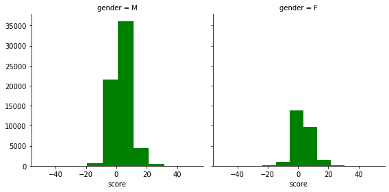

```python
g=sns.FacetGrid(review_df, col='gender',sharex=True, height=4)
g.map(plt.hist, 'score', color ='green');
```

### Comparing distribution of average sentiment score between gender

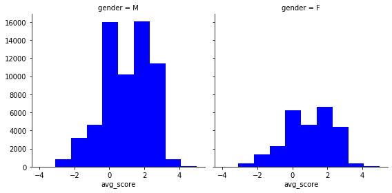

```python
g=sns.FacetGrid(review_df, col='gender',sharex=True, height=4)
g.map(plt.hist, 'avg_score', color ='blue');
```

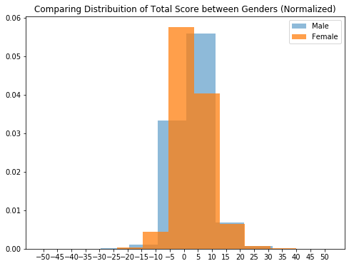

```python
plt.figure(figsize=(8,6));
plt.hist(review_df['score'][review_df['gender']=='M'], label = 'Male', density= True, alpha = 0.5);
plt.hist(review_df['score'][review_df['gender']=='F'], label = 'Female', density = True, alpha = 0.75);
plt.legend();
plt.xticks(np.arange(-50,51,5));
plt.title('Comparing Distribuition of Total Score between Genders (Normalized)', fontsize = 12, loc = 'center');
```

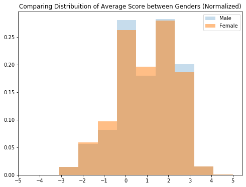

```python
plt.figure(figsize=(8,6));
plt.hist(review_df['avg_score'][review_df['gender']=='M'], label = 'Male', density= True, alpha = 0.25);
plt.hist(review_df['avg_score'][review_df['gender']=='F'], label = 'Female', density = True, alpha = 0.5);
plt.legend();
plt.xticks(np.arange(-5,6,1));
plt.title('Comparing Distribuition of Average Score between Genders (Normalized)', fontsize = 12, loc = 'center');
```

```python
doc_review['hp_id'] = doc_review['hp_id'].map(lambda x: str(x))
```

```python
sanction = doc_review[['hp_id','hasorder']]
```

```python
review_df = pd.merge(review_df,sanction, on = 'hp_id', how = 'left')
```

### Calculate the average score of each doctor

```python
score_df = review_df.groupby(by=['hp_id'])['avg_score'].sum()
```

```python
score_df2 = review_df.groupby(by=['hp_id'])['Review'].count()
```

```python
score_df3 = review_df[review_df['score']!=0].groupby(by=['hp_id'])['Review'].count()
```

```python
score_df = pd.merge(score_df, score_df2, on='hp_id')
```

```python
score_df = pd.merge(score_df, score_df3, on='hp_id')
```

```python
score_df = pd.merge(score_df, review_df[['hp_id','gender','hasorder']], on='hp_id')
```

```python
score_df.rename(mapper={'Review_x':'Total_num of Reviews', 'Review_y':'Total_num of reviews used', 'avg_score':'total_avg_score'}, axis=1, inplace = True)
```

```python
score_df.head()
```

|  | hp_id | total_avg_score | Total_num of Reviews | Total_num of reviews used | gender | hasorder |
| --- | --- | --- | --- | --- | --- | --- |
| 0 | 1000133 | 2.0 | 1 | 1 | M | 0 |
| 1 | 1000546 | 9.5 | 4 | 4 | M | 0 |
| 2 | 1000546 | 9.5 | 4 | 4 | M | 0 |
| 3 | 1000546 | 9.5 | 4 | 4 | M | 0 |
| 4 | 1000546 | 9.5 | 4 | 4 | M | 0 |

```python
score_df['avg_score'] = score_df['total_avg_score']/score_df['Total_num of reviews used']
```

```python
score_df.head()
```

|  | hp_id | total_avg_score | Total_num of Reviews | Total_num of reviews used | gender | hasorder | avg_score |
| --- | --- | --- | --- | --- | --- | --- | --- |
| 0 | 1000133 | 2.0 | 1 | 1 | M | 0 | 2.000 |
| 1 | 1000546 | 9.5 | 4 | 4 | M | 0 | 2.375 |
| 2 | 1000546 | 9.5 | 4 | 4 | M | 0 | 2.375 |
| 3 | 1000546 | 9.5 | 4 | 4 | M | 0 | 2.375 |
| 4 | 1000546 | 9.5 | 4 | 4 | M | 0 | 2.375 |

Statistics of avg_score of doctors who received sanctions

```python
score_df['avg_score'][score_df['hasorder']=='1'].describe()
```

```
count    554.000000
mean       0.987115
std        1.043314
min       -2.500000
25%        0.450000
50%        0.974928
75%        1.916270
max        3.500000
Name: avg_score, dtype: float64
```

Statistics of avg_score of doctors who never receive sanctions

```python
score_df['avg_score'][score_df['hasorder']=='0'].describe()
```

```
count    83942.000000
mean         1.196464
std          1.017958
min         -4.000000
25%          0.607692
50%          1.276203
75%          1.977778
max          5.000000
Name: avg_score, dtype: float64
```

Statistics of avg_score of male doctors

```python
score_df['avg_score'][score_df['gender']=='M'].describe()
```

```
count    59347.000000
mean         1.221599
std          1.030881
min         -4.000000
25%          0.634560
50%          1.321742
75%          2.000000
max          5.000000
Name: avg_score, dtype: float64
```

Statistics of avg_score of female doctors

```python
score_df['avg_score'][score_df['gender']=='F'].describe()
```

```
count    25149.000000
mean         1.132539
std          0.985034
min         -4.000000
25%          0.538462
50%          1.166667
75%          1.833333
max          5.000000
Name: avg_score, dtype: float64
```

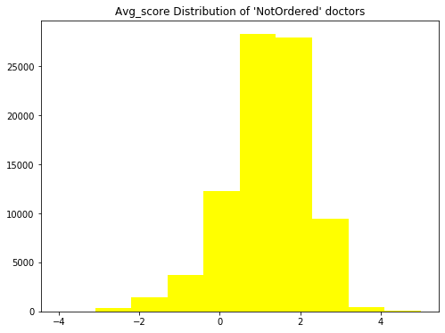

```python
plt.figure(figsize= (8,6))
plt.hist(score_df['avg_score'][score_df['hasorder']=='0'], label = 'No sanction', color = 'yellow');
# sns.distplot(score_df['score'][score_df['hasorder']==0],hist = True, kde=False,rug=True);
# plt.xticks(np.arange(-100,400,50));
plt.title('Avg_score Distribution of \'NotOrdered\' doctors', fontsize = 12, loc = 'center');
```

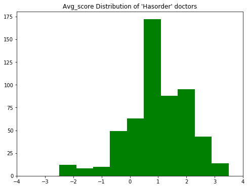

```python
plt.figure(figsize= (8,6))
plt.hist(score_df['avg_score'][score_df['hasorder']=='1'], label = 'Has sanction',color = 'green');
plt.title('Avg_score Distribution of \'Hasorder\' doctors', fontsize = 12, loc = 'center');
plt.xticks(np.arange(-4,5,1));
```

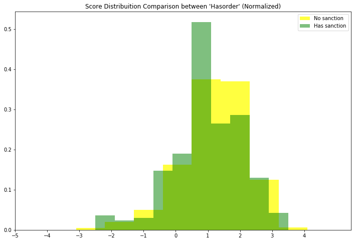

```python
plt.figure(figsize=(12,8));
plt.hist(score_df['avg_score'][score_df['hasorder']=='0'], label = 'No sanction', color = 'yellow', density=True,alpha=0.75);
plt.hist(score_df['avg_score'][score_df['hasorder']=='1'], label = 'Has sanction', color = 'green', density=True, alpha=0.5);
plt.legend();
plt.xticks(np.arange(-5,5,1));
plt.title('Score Distribuition Comparison between \'Hasorder\' (Normalized)', fontsize = 12, loc = 'center');
```

```python
score_df['hasorder'] = score_df['hasorder'].map(lambda x: str(x))
```

### Normalized distribution of average score comparison between 'hasorder' and 'gender

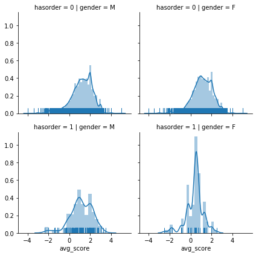

```python
g2 = sns.FacetGrid(score_df, row='hasorder', col='gender',sharex=True)
g2.map(sns.distplot, 'avg_score', rug=True);
```

```python
df3 = pd.crosstab(index = score_df.gender, columns = score_df.hasorder)
df3['percentage'] = df3['1']/df3['0']
```

```python
df3
```

| hasorder gender | 0 | 1 | percentage |
| --- | --- | --- | --- |
| F | 25031 | 118 | 0.004714 |
| M | 58911 | 436 | 0.007401 |